# A3: Incarceration

### Introduction

The impact of racial discrimination in the United States is in every aspect, especially in the prison system. Discrimination against people of color in judicial sentencing has resulted in serious inequitable outcomes for communities of color. Through data visualization, we can more visually see how this inequality has changed from the past to the present and the magnitude of the problem now. This can help the justice system now react to itself and be more fair in sentencing

Year: In order to study changes in the impact of racial discrimination on the justice system, the year is the most intuitive data.

State: This variable helps me to examine how the proportion of people of color incarcerated in prisons geographically.

Gender: In order to study whether there is gender discrimination in the prison system, data on gender must be the most intuitive.

Race: This variable describes what races are in prisons and jails. In order to study whether there is racial discrimination in the prison system, data on race is critical.

Total Prison Population/Total Jail Population: This variable shows how many people are in prison and jail and can help me explain the distribution of the population by race or gender.

### Summary Information

By tabulating the prison and jail population of the Vera Institution, I found that there are years where data for some variables are missing, so below, for better analysis of the data, I will choose to use the most recent year where data for that variable is complete.

In 2013, the total prison population in the United States was 1218724, 501201 of which were black. The state with the highest total prison black population was Los Angeles County with 24296, however the state with the highest total black prison popuilation was Texas with 53615. Moreover, before 2018, the number of blacks in prison was 1.3597 times the number of whites, yet the number of blacks in prison is similar to or even a little less than the number of whites, with an average of 80.9534 and 88.9 per year, respectively.

### The Dataset

In December 2015, Vera released the Incarceration Trends data tool, which employed two Bureau of Justice Statistics (BJS) data collections. Then they made updates in the following years. Two BJS data collections are the Census of Jails (COJ), and the Annual Survey of Jails (ASJ). COJ. The former covers data from almost all jails and the latter covers data from one third of jails. This dataset was made by using information collected by BJS, which contains the data from National Corrections Reporting Program (NCRP), Deaths in Custody Reporting Program: Jail Populations (DCRP), ASJ and COJ. According to the codebook from Vera Institution, NCRP has collected individual-level data on admissions and releases since 1983; data from DCRP is for facility-level jail population and admissions data collected between 2000 and 2013; ASJ has collected data for a sample of counties since 1982; COJ provides data on all counties since its first collection in 1970. In addition, this dataset contains population estimates and geographic information of the US.

There are 153811 observations in the dataset of both prison and jail population per county/state. And there are 36 features in the dataset of prison population per county/state and There are 28 features in the dataset of jail population per county/state.

The biggest limitation of this dataset is that some years are missing data. In the table for the prison population, only the population numbers available for 1970 to 1977. The jail population numbers are missing. So, when I wanted to analyze the questions related to jail population counts, I had to ignore those years. Had these data not been true, the conclusions I reached would have been more complete. At the same time, the tabular data for the prison population are more severely missing. The most recent year with more complete data is 2013, five years removed from the final year. It is possible that the U.S. prison system will get better in those five years, or it is possible that the discrimination problem will get worse. The results obtained using the 2013 data are somewhat outdated now. Moreover, the gender breakdown in these tables is only male and female and does not take the LGBTQ community into account very well. It is possible that until the 21st century, little attention was paid to minorities, but with the data since then I think it is important to take minorities into account when counting the total population of each gender in prisons.

### Trends Over Time Chart

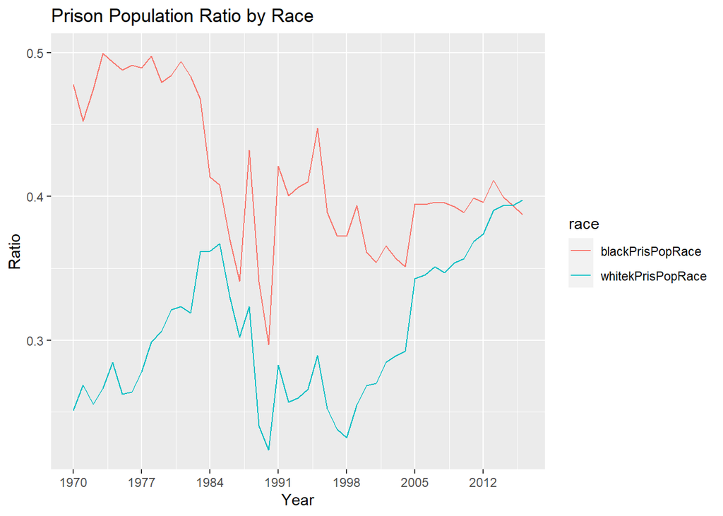

### Variable Comparison Chart

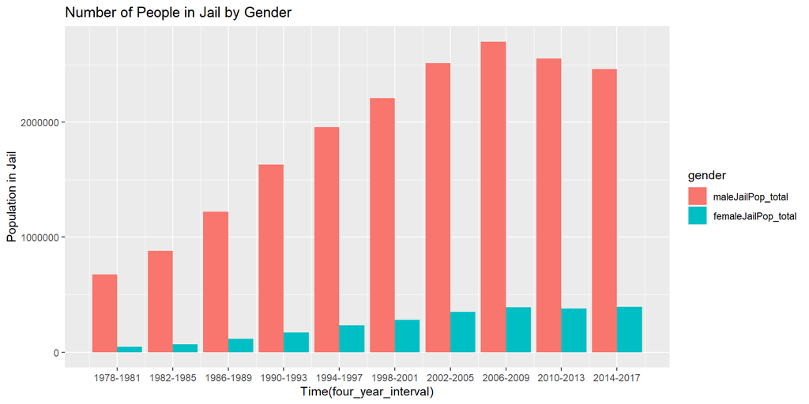

This is a chart on the distribution of the number of males and females in jail. The discrimination in jail may not only be racial but also gender. To make the table more concise and intuitive, I chose to group every four years and come up with data for each gender. By looking at the chart, it is clear that the number of males in prison is much higher than the number of females. Unlike usual, men are more likely to be in jail than women. There is indeed gender discrimination in the prison system and it seems that men are at a disadvantage.

### Map

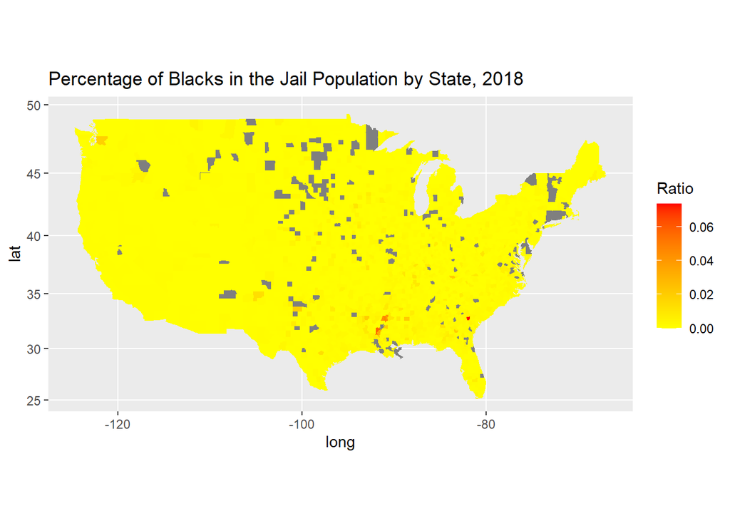